# Supervised Learning

## Linear Regression

LinearRegression fits a linear model with coefficients $w = (w1,...,w_p)$ to minimize the residual sum of squares between the observed responses in the dataset, and the responses predicted by the linear approximation.

### Linear Regression Example

In this example, we'll be working with data on the average life expectancy at birth and the average BMI for males across the world. It includes three columns, containing the following data:

- Country – The country the person was born in.
- Life expectancy – The average life expectancy at birth for a person in that country.
- BMI – The mean BMI of males in that country.

```python
import pandas as pd
from sklearn.linear_model import LinearRegression

import warnings
warnings.simplefilter('ignore')
```

```python
# Import the data using Pandas DataFrame
bmi_life_data = pd.read_csv('CSV/bmi_and_life_expectancy.csv')
bmi_life_data.head()
```

|  | Country | Life expectancy | BMI |
| --- | --- | --- | --- |
| 0 | Afghanistan | 52.8 | 20.62058 |
| 1 | Albania | 76.8 | 26.44657 |
| 2 | Algeria | 75.5 | 24.59620 |
| 3 | Andorra | 84.6 | 27.63048 |
| 4 | Angola | 56.7 | 22.25083 |

```python
# Assign the dataframe to variables
bmi_data = bmi_life_data[['BMI']]
life_data = bmi_life_data[['Life expectancy']]

# Create a model and fit the data
bmi_life_model = LinearRegression()
bmi_life_model.fit(bmi_data, life_data)

# Predictions using BMI values.
life_exp = bmi_life_model.predict([[25.11]]) # Depreciated to simply (25.11)
print('Your life expectancy is {}.'.format(life_exp[0][0]))
```

```
Your life expectancy is 70.4668570534752.
```

```python
import matplotlib.pyplot as plt

plt.figure()
plt.scatter(bmi_data, life_data)
plt.plot(bmi_data, bmi_life_model.predict(bmi_data))
plt.show()
```

[output not shown]

Above, we can predict life expectancy using BMI. Here, BMI is the predictor, also known as an independent variable. A predictor is a variable used in order to make predictions about other variables, while the values you are trying to predict are known as dependent variables. In this case, life expectancy was the dependent variable.

### Multiple Linear Regression

Now, let’s say we get new data on each person’s heart rate as well. Can we create a prediction of life expectancy using both BMI and heart rate?

Absolutely! If the outcome we want to predict depends on more than one variable, we can make a more complicated model that takes this into account. As long as they're relevant to the situation, using more independent/predictor variables can help get a better prediction.

When there's just one predictor, the linear regression model is a line, but as you add more predictor variables, you're adding more dimensions to the picture.

> $y = mx + b$

Adding a predictor variable to go to two predictor variables means that the predicting equation is:

> $y = m_1x_1 + m_2x_2 + b$

To represent this graphically, we use a three-dimensional plot, with the linear regression model represented as a plane.

We can use more than two predictor variables - in fact, we should use as many as are useful! As we make a model with more predictor variables, it becomes harder to visualise, but luckily, everything else about linear regression stays the same. We can still fit models and make predictions in exactly the same way.

```python
from sklearn.linear_model import LinearRegression
from sklearn.datasets import load_boston

# Load the data from the boston house-prices dataset
boston_data = load_boston()
x = boston_data['data']
y = boston_data['target']

# Make and fit the linear regression model
model = LinearRegression()
model.fit(x, y)

# Make a prediction using the model
sample_house = [[2.29690000e-01, 0.00000000e+00, 1.05900000e+01, 0.00000000e+00, 4.89000000e-01,
                6.32600000e+00, 5.25000000e+01, 4.35490000e+00, 4.00000000e+00, 2.77000000e+02,
                1.86000000e+01, 3.94870000e+02, 1.09700000e+01]]
prediction = model.predict(sample_house)

print('The value of the sample houe is {:.2f}K.'.format(prediction[0]))
```

```
The value of the sample houe is 23.68K.
```

### Polynomial Regression

Polynomial regression is a form of regression analysis in which the relationship between the independent/predictor variable $x$ and the dependent variable $y$ is modelled as an nth degree polynomial of $x$. Sklearn's PolynomialFeatures class extends the predictor feature column into multiple columns depending on the degree parameter. Afterwards, we use LinearRegression to fit our data and make predictions.

```python
from sklearn.preprocessing import PolynomialFeatures
import numpy as np

# Reading the data
train_data = pd.read_csv('CSV/poly_reg.csv')
print(train_data.head(5))

# Spliting the data into X and y.
X = train_data['Var_X'].values.reshape(-1,1)
y = train_data['Var_Y'].values
```

```
     Var_X    Var_Y
0 -0.33532  6.66854
1  0.02160  3.86398
2 -1.19438  5.16161
3 -0.65046  8.43823
4 -0.28001  5.57201
```

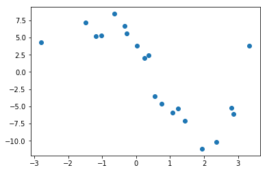

```python
# Ploting the data to see it is a polynomial
plt.scatter(X, y)
plt.show()
```

```python
# Initalizng and fitting the model
poly_feat = PolynomialFeatures(degree = 4)
X_poly = poly_feat.fit_transform(X)
model = LinearRegression().fit(X_poly, y)

# Note that X is split into Degree + 1 columns
print('Original shape of X: {}'.format(X.shape))
print('Polynomial Features shape of X: {}'.format(X_poly.shape)) #Note the shape o
```

```
Original shape of X: (20, 1)
Polynomial Features shape of X: (20, 5)
```

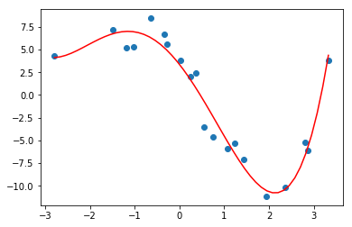

```python
# Create new x values from min to max to plot
x_plot = np.linspace(X.min(), X.max(), 50).reshape(-1,1)

# Predict y from the new x_values
y_plot = model.predict(poly_feat.fit_transform(x_plot))

# Plotting the polynomial regression model
plt.scatter(X,y)
plt.plot(x_plot, y_plot, color='red')
plt.show()
```

### [Regularization](https://towardsdatascience.com/regularization-in-machine-learning-76441ddcf99a)

Regularization is the process of punishing more complex models to avoid overfitting the data. L1 regularization adds the absolute value of coefficient of the model. L2 regularization adds the squares of the coefficient of the model. The λ Parameter controls the degree to punish the model for complexity.

[figure not shown]

In the example below, we use sklearn's Lasso class to fit a linear regression model to the data while using L1 regularization to control for model complexity.

```python
# Import the data
train_data = pd.read_csv('CSV/regularization.csv', header=None)
train_data.head()
```

|  | 0 | 1 | 2 | 3 | 4 | 5 | 6 |
| --- | --- | --- | --- | --- | --- | --- | --- |
| 0 | 1.25664 | 2.04978 | -6.23640 | 4.71926 | -4.26931 | 0.20590 | 12.31798 |
| 1 | -3.89012 | -0.37511 | 6.14979 | 4.94585 | -3.57844 | 0.00640 | 23.67628 |
| 2 | 5.09784 | 0.98120 | -0.29939 | 5.85805 | 0.28297 | -0.20626 | -1.53459 |
| 3 | 0.39034 | -3.06861 | -5.63488 | 6.43941 | 0.39256 | -0.07084 | -24.68670 |
| 4 | 5.84727 | -0.15922 | 11.41246 | 7.52165 | 1.69886 | 0.29022 | 17.54122 |

```python
# Split the data to predictor and outcome variables
X = train_data.iloc[:,:-1]
y = train_data.iloc[:,-1]
print('Shape of X: {}, of y: {}'.format(X.shape, y.shape))
```

```
Shape of X: (100, 6), of y: (100,)
```

```python
# Create and fit the linear regression model with lasso regularization.
from sklearn.linear_model import Lasso
lasso_reg = Lasso()
lasso_reg.fit(X, y)

# Retrieve and print out the coefficients from the regression model.
reg_coef = lasso_reg.coef_
print(reg_coef)
```

```
[ 0.          2.35793224  2.00441646 -0.05511954 -3.92808318  0.        ]
```

### Feature Scaling

Feature scaling is a way of transforming your data into a common range of values. There are two common scalings:

1. Standardizing
2. Normalizing

#### Standardizing

Standardizing is completed by taking each value of within a column, subtracting the mean of the column, and then dividing by the standard deviation of the column. Example:

```
df["height_standard"] = (df["height"] - df["height"].mean()) / df["height"].std()
```

This will create the new "standardized" column where each value is a comparison to the mean of the column. The new "standardized" value can be interpreted as the number of standard deviations the original height was from the mean. This type of feature scaling is by far the most common of all techniques.

#### Normalizing

A second type of feature scaling that is popular is known as normalizing. With normalizing, data are scaled between 0 and 1. Example:

```
df["height_normal"] = (df["height"] - df["height"].min()) / (df["height"].max() - df['height'].min())
```

#### When Should I Use Feature Scaling?

1. When your algorithm uses a distance-based metric to predict.
   - One common supervised learning technique that is based on the distance points are from one another called Support Vector Machines (or SVMs).
   - Another technique that involves distance based methods to determine a prediction is k-nearest neighbors (or k-nn).
   - With either of these techniques, choosing not to scale the data may lead to drastically different (and likely misleading) ending predictions.
2. When you incorporate regularization.
   - The penalty on particular coefficients in regularized linear regression techniques depends largely on the scale associated with the features. When one feature is on a small range, say from 0 to 10, and another is on a large range, say from 0 to 1 000 000, applying regularization is going to unfairly punish the feature with the small range.

Below is the same regularization problem as before but with features scaled:

```python
from sklearn.preprocessing import StandardScaler

# Assign the data to predictor and outcome variables
train_data = pd.read_csv('CSV/regularization.csv', header=None)
X = train_data.iloc[:,:-1]
y = train_data.iloc[:,-1]

# Create the standardization scaling and scale the data.
scaler = StandardScaler()
X_scaled = scaler.fit_transform(X)

# Create and fit the linear regression model with lasso regularization.
lasso_reg2 = Lasso()
lasso_reg2.fit(X_scaled, y)

# Retrieve and print out the coefficients from the regression model.
reg_coef2 = lasso_reg2.coef_
np.set_printoptions(precision = 2)
print('Lasso without scaling: {}'.format(reg_coef))
print('Lasso with scaling: {}'.format(reg_coef2))
```

```
Lasso without scaling: [ 0.    2.36  2.   -0.06 -3.93  0.  ]
Lasso with scaling: [  0.     3.91   9.03  -0.   -11.78   0.45]
```

### Recap

- **Gradient descent** as a method to optimize linear models.
- **Multiple Linear Regression** as a technique for when comparing more than two variables.
- **Polynomial Regression** for relationships between variables that aren't linear.
- **Regularization** as a technique to assure that models will not only fit to the data available, but also extend to new situations.

## Perceptron Algorithm

The perceptron algorithm is an algorithm for classifying data. It is the building block of neural networks.

### Linear Boundaries

> $w_1x_1 + w_2x_2 + b = 0$

$x_1$ is one input, $x_2$ is the other input for a decision of yes or no. It is simplified to:

> $Wx + b = 0$

> $W = (w_1, w_2)$

> $x = (x_1, x_2)$

The product of the two vectors $W$ and $x$ plus the bias ($b$). Multiple dimensions for multiple input (x). The size for $W: (1 x n)$, $x: (n x 1)$, and $b: (1 x 1)$.

Perceptron Coding Example: For a point with coordinates $(p,q)$, label $y$, and prediction given by the equation $\hat{y} = step(w_1x_1 + w_2x_2 + b)$:

- If the point is correctly classified, do nothing.
- If the point is classified positive, but it has a negative label, subtract $αp$, $αq$, and $α$ from $w_1$, $w_2$, and $b$ respectively.
- If the point is classified negative, but it has a positive label, add $αp$, $αq$, and $α$ from $w_1$, $w_2$, and $b$ respectively.

```python
# Setting the random seed, feel free to change it and see different solutions.
np.random.seed(42)

def stepFunction(t):
    if t >= 0:
        return 1
    return 0

def prediction(X, W, b):
    return stepFunction((np.matmul(X,W)+b)[0])

# The function should receive as inputs the data X, the labels y,
# the weights W (as an array), and the bias b,
# update the weights and bias W, b, according to the perceptron algorithm,
# and return W and b.
def perceptronStep(X, Y, W, b, learn_rate = 0.01):
    # Fill in code
    for x, y in zip(X,Y):
        # Calculate the prediction
        y_hat = prediction(x,W,b)
        # Negative points classified postive
        if (y - y_hat == 1):
            W += (x.reshape(-1,1) * learn_rate)
            b += learn_rate
        # Positive points classified negative
        elif (y - y_hat == -1):
            W -= (x.reshape(-1,1) * learn_rate)
            b -= learn_rate
    return W, b

# This function runs the perceptron algorithm repeatedly on the dataset,
# and returns a few of the boundary lines obtained in the iterations,
# for plotting purposes.
# Feel free to play with the learning rate and the num_epochs,
# and see your results plotted below.
def trainPerceptronAlgorithm(X, y, learn_rate = 0.01, num_epochs = 25):
    x_min, x_max = min(X.T[0]), max(X.T[0])
    y_min, y_max = min(X.T[1]), max(X.T[1])
    W = np.array(np.random.rand(2,1))
    b = np.random.rand(1)[0] + x_max
    # These are the solution lines that get plotted below.
    boundary_lines = []
    for i in range(num_epochs):
        # In each epoch, we apply the perceptron step.
        W, b = perceptronStep(X, y, W, b, learn_rate)
        boundary_lines.append((-W[0]/W[1], -b/W[1]))
    return boundary_lines
```

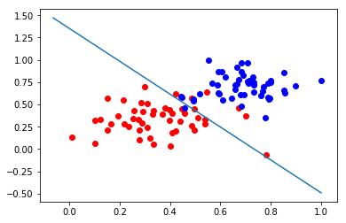

```python
perceptron_data = pd.read_csv('CSV/perceptron.csv', header=None)

# Scatter Plot
X = np.array(perceptron_data.iloc[:,:-1])
Y = np.array(perceptron_data.iloc[:,-1])
for x, y in zip(X,Y):
    if y == 1:
        plt.scatter(x[0],x[1], color='red')
    else:
        plt.scatter(x[0],x[1], color='blue')

# Perceptron Line Plot
train = trainPerceptronAlgorithm(X,Y)
W = train[-1][0][0]
b = train[-1][1][0]
x_plot = np.linspace(X.min(),X.max(),10)
y_plot = (W * x_plot) + b
plt.plot(x_plot, y_plot);
```

**NOTE** Plotting using Numpy Arrays

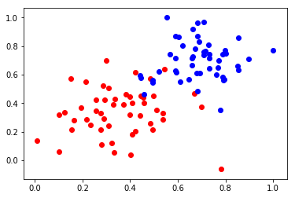

```python
perceptron_data = pd.read_csv('CSV/perceptron.csv', header=None)
X = np.array(perceptron_data.iloc[:,:-1])
Y = np.array(perceptron_data.iloc[:,-1])
for i, y in enumerate(Y):
    if y == 1:
        plt.scatter(X[i,0],X[i,1], color='red')
    else:
        plt.scatter(X[i,0],X[i,1], color='blue')
```

**NOTE** Plotting using Pandas DataFrame

```
<class 'pandas.core.frame.DataFrame'> <class 'pandas.core.series.Series'>
```

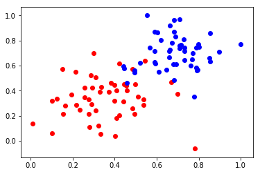

```python
perceptron_data = pd.read_csv('CSV/perceptron.csv', header=None)
X = perceptron_data.iloc[:,:-1]
Y = perceptron_data.iloc[:,-1]
print(type(X), type(Y))
for i, y in enumerate(Y):
    if y == 1:
        plt.scatter(X.loc[i,0],X.loc[i,1], color='red')
    else:
        plt.scatter(X.loc[i,0],X.loc[i,1], color='blue')
```

## Decision Trees

Decision trees are a structure for decision-making where each decision leads to a set of consequences or additional decisions.

### Entropy

- Low - no matter the decision tree is organized, it is the same outcome because the data has a clear split (homogeneous) - high knowledge of data
- Medium - few possibilities to organize a decision tree because some data is similar - medium knowledge
- High - many possibilities to organize decision tree because data is not homogeneous - low knowledge of the data

  > $Entropy = -\frac{m}{m+n}log_2\frac{m}{m+n} - \frac{n}{m+n}log_ \frac{n}{m+n}$

```python
import math
m = 4
n = 10
- m / (m+n) * math.log(m/(m+n)) - n / (m+n) * math.log(n/(m+n))
```

```
0.5982695885852573
```

### Multi-class Entropy

Entropy for two classes:

> $p_1 = \frac{m}{m+n}$

> $p_2 = \frac{n}{m+n}$

> $entropy = -p_1\log_2(p_1)-p_2\log_2(p_2)$

This entropy equation can be extended to the multi-class case, where we have three or more possible values:

> $entropy = -p_1\log_2(p_1) - p_2\log_2(p_2) - ... - p_n\log_2(p_n) = -\sum\limits_{i=1}^n p_i\log_2(p_i) $

The minimum value is still 0, when all elements are of the same value. The maximum value is still achieved when the outcome probabilities are the same, but the upper limit increases with the number of different outcomes. (For example, you can verify the maximum entropy is 2 if there are four different possibilities, each with probability 0.25.)

```python
p1 = 8 / 13
p2 = 3 / 13
p3 = 2 / 13
-(p1 * np.log2(p1) + p2 * np.log2(p2) + p3 * np.log2(p3))
```

```
1.3346791410515946
```

### Information Gain Formula

The average entropy for the child groups will need to be a weighted average, based on the number of cases in each child group. That is, for $m$ items in the first child group and $n$ items in the second child group, the information gain is:

$\mathrm{Information\;Gain} = \mathrm{Entropy}(Parent) - \left[\frac{m}{m+n}\mathrm{Entropy}(Child_1) + \frac{n}{m+n}\mathrm{Entropy}(Child_2)\right]$

### Hyperparameters for Decision Trees

- Maximum Depth - k depth at most $2^{k}$
- Minumum Number of Samples to Split - if too little, sample should not be split
- Minumum Number of Samples per Leaf - if the split causes a leaf to have too little values, do not split

### Overfitting & Underfitting

Large depth very often causes overfitting, since a tree that is too deep, can memorize the data. Small depth can result in a very simple model, which may cause underfitting.

Small minimum samples per split may result in a complicated, highly branched tree, which can mean the model has memorized the data, or in other words, overfitting. Large minimum samples may result in the tree not having enough flexibility to get built, and may result in underfitting.

```python
from sklearn.tree import DecisionTreeClassifier

model = DecisionTreeClassifier(max_depth = 5, min_samples_leaf = 3)
```

```python
data = np.asarray(pd.read_csv('CSV/decision_tree.csv'))
X = data[:,:-1]
y = data[:,-1]
```

```python
model.fit(X, y)
```

```
DecisionTreeClassifier(class_weight=None, criterion='gini', max_depth=5,
            max_features=None, max_leaf_nodes=None,
            min_impurity_decrease=0.0, min_impurity_split=None,
            min_samples_leaf=3, min_samples_split=2,
            min_weight_fraction_leaf=0.0, presort=False, random_state=None,
            splitter='best')
```

### Accuracy

To check accuracy of the model, we utilize sklearn.metrics `accuracy_score` on the original input data ($X$) and compare it to our output data ($y$).

```python
from sklearn.metrics import accuracy_score

y_pred = model.predict(X)
acc = accuracy_score(y,y_pred)
print(acc)
```

```
0.968421052631579
```

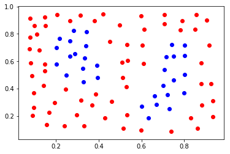

```python
for x, y in zip(X, y):
    if y == 0:
        plt.scatter(x[0],x[1], color='blue')
    else:
        plt.scatter(x[0],x[1], color='red')
```

```python
from sklearn.datasets import load_iris
from sklearn import tree
iris = load_iris()
clf = tree.DecisionTreeClassifier()
clf = clf.fit(iris.data, iris.target)

import graphviz
dot_data = tree.export_graphviz(clf, out_file=None)
graph = graphviz.Source(dot_data)
graph.render("iris")

dot_data = tree.export_graphviz(clf, out_file=None,
                      feature_names=iris.feature_names,
                      class_names=iris.target_names,
                      filled=True, rounded=True,
                      special_characters=True)
graph = graphviz.Source(dot_data)
graph
```

[figure not shown]

## Naive Bayes

### Bayes Theorem

Naive Bayesian Algorithms are powerful tools for creating classifiers for incoming labeled data. Specifically for Naive Bayes is frequently used with text data and classification problems.

We know the probability of A, P(A) and the probability of R given A, P(R|A). We can infer the probability of A given R occurred, P(A|R).

[figure not shown]

Probability of A after the event R occurred.

[figure not shown]

## Support Vector Machines

Support vector machines are a common method for classification problems. Given labeled training data (supervised learning), the algorithm outputs an optimal hyperplane which categorizes new examples. They have been proven effective using what is known as the "kernel" trick.

```
Error = C * Classification Error + Margin Error
```

- Classification Error is the error of misclassified points. C Parameter is the weight we put on classification error depending on the need for spacing the line vs classifyng points correctly. Large C means focusing on classifying point. Small C means focusing on spacing and typically has a large Margin.
- Margin Error is the error of points classified correctly but within the margin `Wx + b = 1` and `Wx + b = -1`. Large Margin leads to Small Error. Small Margin leads to Large Error. $Error = |W|^{2}$ and $Margin = \frac{2}{|W|}$

Minimize Error using Gradiant Descent

[figure not shown]

### Polynomial Kernel

Using higher demensions ($x^{2}, xy, x^{2}$) to classify points.

[figure not shown]

### RBF Kernel

[figure not shown]

### Support Vector Macines in sklearn

```
from sklearn.svm import SVC
mode = SVC()
mode.fit(x_values, y_values)
```

### Hyperparameters

- `C`: The C parameter.
- `kernel`: The kernel. The most common ones are 'linear', 'poly', and 'rbf'.
- `degree`: If the kernel is polynomial, this is the maximum degree of the monomials in the kernel.
- `gamma` : If the kernel is rbf, this is the gamma parameter.

For example, here we define a model with a polynomial kernel of degree 4, and a C parameter of 0.1.

```
model = SVC(kernel = 'poly', degree = 4, C = 0.1)
```

```
Accuracy: 1.00
```

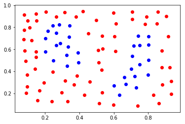

```python
# Import statements
from sklearn.svm import SVC
from sklearn.metrics import accuracy_score
import pandas as pd
import numpy as np

# Read the data.
data = np.asarray(pd.read_csv('CSV/SVM Models.csv', header=None))
# Assign the features to the variable X, and the labels to the variable y.
X = data[:,0:2]
Y = data[:,2]

for x, y in zip(X,Y):
    if y == 1:
        plt.scatter(x[0],x[1], color='red')
    else:
        plt.scatter(x[0],x[1], color='blue')

# TODO: Create the model and assign it to the variable model.
# Find the right parameters for this model to achieve 100% accuracy on the dataset.
model = SVC(kernel = 'rbf', gamma = 20, C = 1.5)

# TODO: Fit the model.
model.fit(X, Y)

# TODO: Make predictions. Store them in the variable y_pred.
y_pred = model.predict(X)

# TODO: Calculate the accuracy and assign it to the variable acc.
acc = accuracy_score(y_pred, Y)
print('Accuracy: {:.2F}'.format(acc))
```

## Ensemble Models

Ensemble methods use multiple learning algorithms to better predict. There are two many methods - bagging and boosting.

#### Why Ensemble?

- High Bias, Low Variance models tend to underfit data, as they are not flexible. Linear models fall into this category of models.
- High Variance, Low Bias models tend to overfit data, as they are too flexible. Decision trees fall into this category of models.

In order to find a way to optimize for both variance and bias, we use ensemble methods. Ensemble methods have become some of the most popular methods used to compete in competitions on Kaggle and used in industry across applications. There are two randomization techniques to combat overfitting:

- Bagging (Bootstrap Aggregating) - that is having each model in the ensemble vote with equal weight based on different samplings of the data (with replacement).
- Subset the features - in each split of a decision tree or with each algorithm used an ensemble only a subset of the total possible features are used.

### Bagging Classifier

A Bagging classifier is an ensemble meta-estimator that fits base classifiers each on random subsets of the original dataset and then aggregate their individual predictions (either by voting or by averaging) to form a final prediction.

[figure not shown]

### RandomnForest Classifier

A random forest is an ensemble meta-estimator that fits a number of decision tree classifiers on various sub-samples of the dataset and uses averaging to improve the predictive accuracy and control over-fitting.

[figure not shown]

### Adapative Boost Classifier

An AdaBoost classifier is an ensemble meta-estimator that begins by fitting a classifier on the original dataset and then fits additional copies of the classifier on the same dataset but where the weights of incorrectly classified instances are adjusted such that subsequent classifiers focus more on difficult cases.

[figure not shown]

Boosting involves incrementally building an ensemble by training each new model instance based on the previous models mistakes. Training time is often longer.

```python
# Import our libraries
import pandas as pd
from sklearn.model_selection import train_test_split
from sklearn.feature_extraction.text import CountVectorizer
from sklearn.naive_bayes import MultinomialNB
from sklearn.metrics import accuracy_score, precision_score, recall_score, f1_score


# Read in our dataset
df = pd.read_table('CSV/SMSSpamCollection',
                   sep='\t',
                   header=None,
                   names=['label', 'sms_message'])

# Fix our response value
df['label'] = df.label.map({'ham':0, 'spam':1})

# Split our dataset into training and testing data
X_train, X_test, y_train, y_test = train_test_split(df['sms_message'],
                                                    df['label'],
                                                    random_state=1)

# Instantiate the CountVectorizer method
count_vector = CountVectorizer()

# Fit the training data and then return the matrix
training_data = count_vector.fit_transform(X_train)

# Transform testing data and return the matrix. Note we are not fitting the testing data into the CountVectorizer()
testing_data = count_vector.transform(X_test)

# Instantiate our model
naive_bayes = MultinomialNB()

# Fit our model to the training data
naive_bayes.fit(training_data, y_train)

# Predict on the test data
predictions = naive_bayes.predict(testing_data)

# Score our model
print('Accuracy score: ', format(accuracy_score(y_test, predictions)))
print('Precision score: ', format(precision_score(y_test, predictions)))
print('Recall score: ', format(recall_score(y_test, predictions)))
print('F1 score: ', format(f1_score(y_test, predictions)))
```

```
Accuracy score:  0.9885139985642498
Precision score:  0.9720670391061452
Recall score:  0.9405405405405406
F1 score:  0.9560439560439562
```

```python
from sklearn.ensemble import BaggingClassifier, RandomForestClassifier, AdaBoostClassifier

# Build the model
bagging_model = BaggingClassifier(n_estimators = 200)
forest_model = RandomForestClassifier(n_estimators = 200)
adaboost_model = AdaBoostClassifier(n_estimators = 300, learning_rate = 0.2)

# Fit the model to training data
bagging_model.fit(training_data, y_train)
forest_model.fit(training_data, y_train)
adaboost_model.fit(training_data, y_train)

# Predict on the test data
bagging_prediction = bagging_model.predict(testing_data)
forest_prediction = forest_model.predict(testing_data)
adaboost_prediction = adaboost_model.predict(testing_data)

print('Accuracy Score for Bagging: {}'.format(accuracy_score(y_test, bagging_prediction)))
print('Accuracy Score for Random Forest: {}'.format(accuracy_score(y_test, forest_prediction)))
print('Accuracy Score for AdaBoost: {}'.format(accuracy_score(y_test, adaboost_prediction)))
```

```
Accuracy Score for Bagging: 0.9755922469490309
Accuracy Score for Random Forest: 0.9834888729361091
Accuracy Score for AdaBoost: 0.9770279971284996
```

## Model Evaluation Metrics

### Training & Testing Data

It is important to always split the data into training and testing to measure how well the model performs on the test set after fitting the training data. Sklearn `train_test_split` splits dataframes into `X_train`, `X_test`, `y_train`, and `y_test`. Classifiers have different measures than regressors.

### Accuracy

Accuracy is often used to compare models, as it tells us the proportion of observations we correctly labeled.

[figure not shown]

Often accuracy is not the only metric to be optimized. This is especially the case there is class imbalance in the data. Optimizing only accuracy can be misleading in how well the model is truly performing.

### Precision

Precision focuses on the predicted "positive" values in the dataset. By optimizing based on precision values, we are determining if the model is doing a good job of predicting the positive values (true positives over all positive predictions).

[figure not shown]

### Recall

Recall focuses on the actual "positive" values in the dataset. By optimizing based on recall values, we are determining if the model is doing a good job of predicting the positive values without regard to the actual negative values (true positives over the sum of true positives and false negatives). To perform something similar to recall on the actual 'negative' values, this is called specificity.

[figure not shown]

### F-Beta Score

In order to look at a combination of metrics at the same time, there are some common techniques like the F-Beta ($F_β$) Score (where the $F_1$ score is frequently used), as well as the ROC and AUC. The β parameter controls the degree to which precision is weighed into the F score. The most common value for beta is 1 - the harmonic average between precision and recall.

$F_β = (1 + β^2)\frac{Precision*Recall}{β^2*Precision + Recall}$

### ROC Curve & AUC

The Receiver Operating Characteristic (ROC) Curve is a graphical plot that illustrates the diagnostic ability of a binary classifier system as its discremination threshold is varied. It is created by plotting true positive rate against the false positive rate at various threshold settings. AUC is the area under the ROC curve. Similar to metrics above, when the AUC is higher (closer to 1), this suggests that the model performance is better than when the metric is close to 0 (perfectly incorrect classifier).

[figure not shown]

It is common to end up using AUC or $F_β$ score often. However, there are always reason to choose one measure over another depending on the situation.

```python
models = [predictions, bagging_prediction, forest_prediction, adaboost_prediction]
model_names = ['Naive Bayes', 'Bagging', 'Random Forest', 'AdaBoost']
for model, name in zip(models, model_names):
    accuracy = accuracy_score(y_test, model)
    percision = precision_score(y_test, model)
    recall = recall_score(y_test, model)
    f1 = f1_score(y_test, model)
    print(name)
    print('Accuracy: {:.4f}, Percision: {:.4f}, Recall: {:.4f}, F1: {:.4f} \n'.format(accuracy, percision, recall, f1))
```

```
Naive Bayes
Accuracy: 0.9885, Percision: 0.9721, Recall: 0.9405, F1: 0.9560

Bagging
Accuracy: 0.9756, Percision: 0.9171, Recall: 0.8973, F1: 0.9071

Random Forest
Accuracy: 0.9835, Percision: 1.0000, Recall: 0.8757, F1: 0.9337

AdaBoost
Accuracy: 0.9770, Percision: 0.9693, Recall: 0.8541, F1: 0.9080
```

### Regression Metrics

There are three main metrics that are frequently used for regression models: mean absolute error, mean squared error, and $R^2$ values. It is important to note, optimizing on the mean absolute error may lead to a different 'best model' than optimizing on the mean squared error. However, optimizing on the mean squared error will always lead to the same 'best' model as optimizing on the $R^2$ value. Choosing one versus another is often based on comfort of explaining to someone else.

### Mean Absolute Error (MAE)

The mean absolute error is a useful metric to optimize on when the values follows a skewed distribution. Using the absolute value is particularly helpful because outliers will not influence the model as the mean squared error. The optimal value for this technique is the median value since the absolute value of the distance from the model would be 0.

### Mean-Squared Error (MSE)

The mean squared error is by far the most used metric for optimization in regression problems. The best fitting model will minimizes this value. This metric can be greatly impacted by skewed distributions and outliers. In many cases, it is easier to actually optimize on MSE, as the a quadratic term is differentiable. However, an absolute value is not differentiable. This factor makes this metric better for gradient based optimization algorithms.

### $R^2$ Score

The $R^2$ value is another common regression metric. It is also known as the coefficient of determination. Optimizing a model to have the lowest MSE will also optimize a model to have the the highest $R^2$ value. The $R^2$ value is frequently interpreted as the 'amount of variability' captured by a model and is calculated as the explained variation over the total variation.

```python
from sklearn.datasets import load_boston
from sklearn.model_selection import train_test_split
from sklearn.tree import DecisionTreeRegressor
from sklearn.ensemble import RandomForestRegressor, AdaBoostRegressor
from sklearn.linear_model import LinearRegression
from sklearn.metrics import r2_score, mean_squared_error, mean_absolute_error
import numpy as np

boston = load_boston()
y = boston.target
X = boston.data

X_train, X_test, y_train, y_test = train_test_split(
            X, y, test_size=0.33, random_state=42)

# Instantiate each of the models you imported
dtr_model = DecisionTreeRegressor()
rfr_model = RandomForestRegressor()
abr_model = AdaBoostRegressor()
lr_model = LinearRegression()

# Fit each of your models using the training data
dtr_model.fit(X_train, y_train)
rfr_model.fit(X_train, y_train)
abr_model.fit(X_train, y_train)
lr_model.fit(X_train, y_train)

# Predict on the test values for each model
dtr_preds = dtr_model.predict(X_test)
rfr_preds = rfr_model.predict(X_test)
abr_preds = abr_model.predict(X_test)
lr_preds = lr_model.predict(X_test)

preds = [dtr_preds, rfr_preds, abr_preds, lr_preds]
preds_names = ['Decision Tree', 'Random Forest', 'Adaptive Boost', 'Linear']

for pred, name in zip(preds,preds_names):
    r2_value = r2_score(y_test, pred)
    mse_value = mean_squared_error(y_test, pred)
    mae_value = mean_absolute_error(y_test, pred)
    print(name)
    print('R2: {:.2f}, MSE: {:.2f}, MAE {:.2f} \n'.format(r2_value, mse_value, mae_value))
```

```
Decision Tree
R2: 0.75, MSE: 18.99, MAE 2.98

Random Forest
R2: 0.82, MSE: 13.95, MAE 2.46

Adaptive Boost
R2: 0.80, MSE: 15.22, MAE 2.68

Linear
R2: 0.73, MSE: 20.72, MAE 3.15
```

## Training and Tuning

### k-Fold Cross Validation

Cross-validation is a resampling procedure used to evaluate machine learning models on a limited data sample. Procedures for k-Fold Cross Validation:

1. Shuffle the dataset randomly.
2. Split the dataset into k groups.
3. For each unique group:
   - Take the group as a hold out or test data set.
   - Take the remaining groups as a training data set.
   - Fit a model on the training set and evaluate it on the test set.
   - Retain the evaluation score and discard the model.
4. Summarize the skill of the model using the sample of model evaluation scores.

### Learning Curves

Learning curves helps to determine if the model is being underfit, overfit, or just right. High training and testing error leads to underfitting. Low training but high testing error leads to overfitting. Low training and testing error means the model is just right.

[figure not shown]

### Hyperparameter Optimization

In machine learning, hyperparameter optimization (tuning) is the problem of choosing a set of optimal hyperparameters for a learning algorithm. The most common is the Grid Search.

[figure not shown]

### [Diabetes Case Study](https://sharmokh.github.io/DiabetesCaseStudy.html)